# Regularization Techniques

Sushma Vijayeendra Karjol

Regularization Techniques  
Instructor : Dr. Vladimir Shapiro

**Introduction**

In this module, we will be using the glmnet package to perform the Ridge Regression and the Lasso Regression. To fit the ridge regression models and lasso models the main function of this package, cv. glmnet() or cross-validation glmnet is used. And, this function has quite a different syntax from other model-fitting functions. A college dataset from the ISLR is used for the study. This study aims to know which model fits well to know the predictions of variable - ‘Graduation rate’ for private and non-private colleges using the rest of the variables as dependents. This is divided into three parts. In the first part, the data set is regularised using the Ridge method, where lambda. min and lambda.1se values are estimated. Then the methods are visually represented and compared. The best fit of the Ridge regression model is set with the train and test dataset. The second part includes the same set of procedures are followed but with LASSO regression. Coefficients of variables are compared for the study to know which one would be the best fit. The third part involves the analysis and discussions.

College Dataset from the library ISLR is a assigned to M4_College

```r
library(ISLR)
attach(College)

M4_College <- College[-1]

# first column has the categorical dataset which is deleted for the study.
```

### 1) Split the data into a train and test set – refer to the ALY6015_Feature_Selection_R.pdf document for information on how to split a dataset.

The dataset is split into training and testing sets. It is the important part of evaluation data mining models. Typically , a large portion of dataset is allocated for training and smaller for testing.

```r
library (caret)
library(lattice)
library(ggplot2)

# spliiting the dataset for th study
set.seed(1520)
trainIndex <- createDataPartition(M4_College$Apps,p=0.7,list=FALSE,times=1)
M4College_train <- M4_College[ trainIndex,]
M4College_test <- M4_College[-trainIndex,]
```

```
The dataset is split into - training and test sets. They differ in size because of the  way the samples are being taken.
  Train dataset is used to fit the model and the test is conducted to  test if the prediction fits the dataset.
```

```r
# provides details of the variables

summary(M4College_train)
```

```
      Apps           Accept          Enroll         Top10perc       Top25perc
 Min.   :   81   Min.   :   72   Min.   :  35.0   Min.   : 1.00   Min.   :  9.00
 1st Qu.:  776   1st Qu.:  614   1st Qu.: 244.0   1st Qu.:15.00   1st Qu.: 40.00
 Median : 1558   Median : 1097   Median : 430.0   Median :24.00   Median : 55.00
 Mean   : 3004   Mean   : 2015   Mean   : 773.4   Mean   :27.42   Mean   : 55.73
 3rd Qu.: 3624   3rd Qu.: 2424   3rd Qu.: 913.0   3rd Qu.:35.00   3rd Qu.: 69.00
 Max.   :48094   Max.   :26330   Max.   :6180.0   Max.   :96.00   Max.   :100.00
  F.Undergrad     P.Undergrad         Outstate       Room.Board       Books
 Min.   :  139   Min.   :    1.0   Min.   : 2340   Min.   :1880   Min.   :  96.0
 1st Qu.:  979   1st Qu.:   86.0   1st Qu.: 7380   1st Qu.:3603   1st Qu.: 470.0
 Median : 1707   Median :  341.0   Median :10100   Median :4230   Median : 500.0
 Mean   : 3666   Mean   :  869.6   Mean   :10484   Mean   :4368   Mean   : 552.7
 3rd Qu.: 4296   3rd Qu.:  963.0   3rd Qu.:12950   3rd Qu.:5050   3rd Qu.: 600.0
 Max.   :28938   Max.   :21836.0   Max.   :20100   Max.   :8124   Max.   :2340.0
    Personal         PhD            Terminal        S.F.Ratio      perc.alumni
 Min.   : 300   Min.   :  8.00   Min.   : 24.00   Min.   : 2.50   Min.   : 0.00
 1st Qu.: 882   1st Qu.: 62.00   1st Qu.: 71.00   1st Qu.:11.50   1st Qu.:13.00
 Median :1200   Median : 75.00   Median : 82.00   Median :13.60   Median :21.00
 Mean   :1362   Mean   : 72.38   Mean   : 79.49   Mean   :14.04   Mean   :22.71
 3rd Qu.:1702   3rd Qu.: 85.00   3rd Qu.: 92.00   3rd Qu.:16.30   3rd Qu.:31.00
 Max.   :6800   Max.   :100.00   Max.   :100.00   Max.   :39.80   Max.   :60.00
     Expend        Grad.Rate
 Min.   : 3186   Min.   : 10.0
 1st Qu.: 6817   1st Qu.: 53.0
 Median : 8377   Median : 66.0
 Mean   : 9612   Mean   : 65.6
 3rd Qu.:10872   3rd Qu.: 78.0
 Max.   :45702   Max.   :118.0
```

```r
# dimension of the dataset
dim(M4College_train)
```

```
[1] 545  17
```

Summary determines the descriptive statistics of the all the variables in the dataset.

### 2) Use the glmnet function to estimate the lambda.min and lambda.1se values. Compare and discuss the values.

```
The glmnet() function conatins alpha argument that provides the model that is fit. If alpha is  0 then a ridge regression model is fit, and if alpha is  1 then a lasso model is fit. First fit Ridge Regression model:
```

```r
library(glmnet)
```

```r
library(dplyr)
library(foreach)
#install.packages("Matrix")
library(Matrix)

train.mat = model.matrix(Grad.Rate~., data=M4College_train)[,-1]

lambda_seq <- 10 ^ seq(2,-2,by = -.1)

mod.ridge = cv.glmnet(x = train.mat, y = M4College_train$Grad.Rate, alpha = 0,lambda=lambda_seq )
mod.ridge
```

```
Call:  cv.glmnet(x = train.mat, y = M4College_train$Grad.Rate, lambda = lambda_seq,      alpha = 0)

Measure: Mean-Squared Error

    Lambda Index Measure    SE Nonzero
min  1.995    18     172 15.77      16
1se 25.119     7     186 17.27      16
```

```r
cat("\n lambda.best \n")
```

```
 lambda.best
```

```r
lambda.best = mod.ridge$lambda.min
lambda.best
```

```
[1] 1.995262
```

```r
cat("\n lambda.lse \n")
```

```
 lambda.lse
```

```r
lambda.1se = mod.ridge$lambda.1se
lambda.1se
```

```
[1] 25.11886
```

```r
test.mat <- model.matrix(Grad.Rate~., data = M4College_test)[,-1]
y = M4College_test$Grad.Rate

alpha_predict <- predict(mod.ridge, s = mod.ridge$lambda.min , newx = test.mat)
```

```r
#glmnet(x, y, alpha = 0.2, weights = wts, nlambda = 20)

fit <- glmnet(train.mat, M4College_train$Grad.Rate , alpha = 0)
```

### 3)Plot the results from the glmnet function, provide an interpretation. What does this plot tell us?

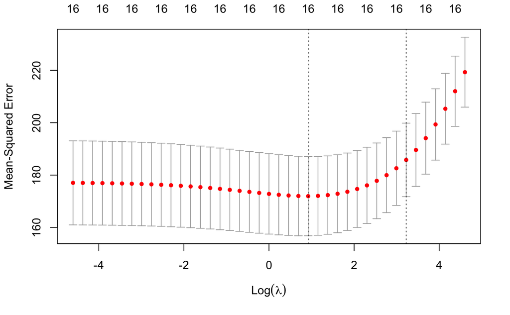

```r
plot(mod.ridge)
```

In Ridge regression we estimate the coefficients of multiple-regression models where the independent variables are highly correlated. The least square values are unbiased , the variances are large and are far away from the true values. Here , Ridge minimizes the residual sum of squares .

### 4) Fit a Ridge regression model against the training set and report on the coefficients. Is there anything interesting?

```r
# Rebuilding the model with best lamda value identified
Ridge_best <- glmnet(x = train.mat, y = M4College_train$Grad.Rate, lambda = lambda.best)
Ridge_best
```

```
Call:  glmnet(x = train.mat, y = M4College_train$Grad.Rate, lambda = lambda.best)

  Df  %Dev Lambda
1  6 39.14  1.995
```

```r
# table of co-efficent values for each variable
coef(Ridge_best)
```

```
17 x 1 sparse Matrix of class "dgCMatrix"
                       s0
(Intercept) 42.7809929441
Apps         .
Accept       .
Enroll       .
Top10perc    0.0589106769
Top25perc    0.0851650613
F.Undergrad  .
P.Undergrad -0.0004624633
Outstate     0.0013289825
Room.Board   .
Books        .
Personal    -0.0002377431
PhD          .
Terminal     .
S.F.Ratio    .
perc.alumni  0.1432326606
Expend       .
```

```r
?glmnet()
```

[output not shown]

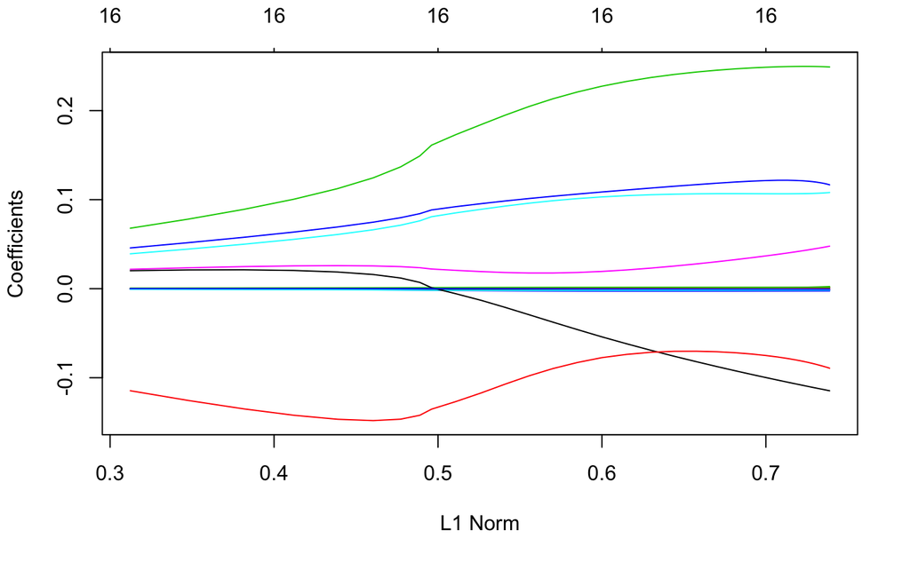

```r
plot(mod.ridge$glmnet.fit)
```

```r
NA
NA
```

[output not shown]

[figure not shown]

```r
# creating matrix for test dataset.
test.mat = model.matrix(Grad.Rate~., data=M4College_test)
```

### 5) Determine the performance of the fit model against the training set by calculating the root mean square error (RMSE). sqrt(mean((actual - predicted)^2))

```r
# RMSE calculaton for train data set

Ridge_best # model created using best lmada value
```

```
Call:  glmnet(x = train.mat, y = M4College_train$Grad.Rate, lambda = lambda.best)

  Df  %Dev Lambda
1  6 39.14  1.995
```

```r
alpha_predictTrain <- predict(Ridge_best, s = lambda.best , newx = train.mat)

predict <- alpha_predictTrain

cat ("\n Root mean square value of Ridge regression against train dataset \n")
```

```
 Root mean square value of Ridge regression against train dataset
```

```r
sqrt(mean((M4College_train$Grad.Rate - predict)^2))
```

```
[1] 13.43388
```

[output not shown]

### 6) Determine the performance of the fit model against the test set by calculating the root mean square error (RMSE). Is your model overfit?

```r
# matrix for train dataset
test.mat = model.matrix(Grad.Rate~., data = M4College_test)[,-1]


y = M4College_test$Grad.Rate

fit <- glmnet(x = test.mat, y = M4College_test$Grad.Rate)

alpha_predictTest <- predict(Ridge_best, s = lambda.best , newx = test.mat)

actualTest <- mod.ridge
predictTest <- alpha_predictTest

cat ("\n Root mean square value of Ridge regression against test dataset \n")
```

```
 Root mean square value of Ridge regression against test dataset
```

```r
sqrt(mean((M4College_test$Grad.Rate - predictTest)^2))
```

```
[1] 13.37291
```

### 7) Use the cv.glmnet function to estimate the min and lambda.1se values. Compare and discuss the values.

```r
lambda_seqLasso <- 10^seq(2, -2, by = -.1)

mod.lasso = cv.glmnet(train.mat, M4College_train$Grad.Rate, alpha=1 ,lambda = lambda_seqLasso)
mod.lasso
```

```
Call:  cv.glmnet(x = train.mat, y = M4College_train$Grad.Rate, lambda = lambda_seqLasso,      alpha = 1)

Measure: Mean-Squared Error

    Lambda Index Measure    SE Nonzero
min 0.3162    26   172.1 15.48      11
1se 1.9953    18   185.8 14.70       6
```

```r
lambda.bestLasso = mod.lasso$lambda.min
lambda.bestLasso
```

```
[1] 0.3162278
```

```r
lambda.1se = mod.lasso$lambda.1se
lambda.1se
```

```
[1] 1.995262
```

[output not shown]

### 8) Plot the results from the glmnet function, provide an interpretation. What does this plot tell us?

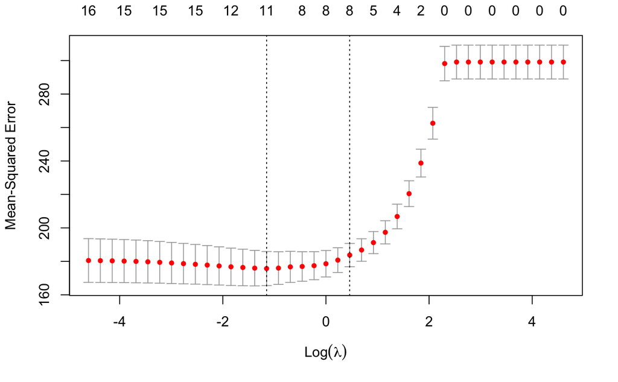

```r
plot(mod.lasso)
```

[output not shown]

### 9) Fit a LASSO regression model against the training set and report on the coefficients. Do any coefficients reduce to zero? If so, which ones?

```r
lasso_best <- glmnet(x = train.mat, y = M4College_train$Grad.Rate, lambda = lambda.bestLasso)
lasso_best
```

[output not shown]

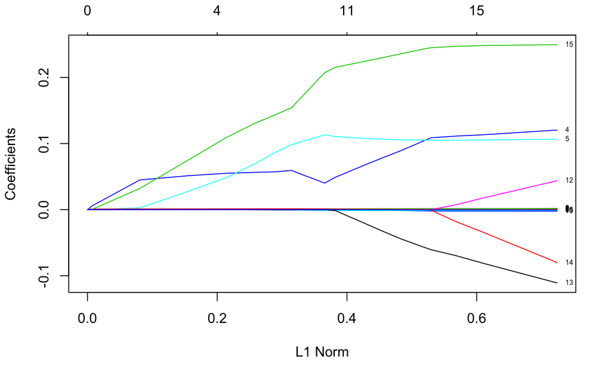

```r
#predict(mod.lasso, s = mod.lasso$lambda.1se , newx =)
#predict(mod.lasso, s=lambda.best, type="coefficients")

plot(mod.lasso$glmnet.fit , label = TRUE)
```

```
The above graph measure the multi-linear complexity of the model. This is graphically explained against train data set.There are several co-efficient values that are blowing-up at the end of the path. Along side coefficient of few variables are suppressed to zero.
```

```r
coef(lasso_best)
```

```
17 x 1 sparse Matrix of class "dgCMatrix"
                       s0
(Intercept) 40.8651778076
Apps         0.0005533179
Accept       .
Enroll       .
Top10perc    0.0798603795
Top25perc    0.1060521441
F.Undergrad  .
P.Undergrad -0.0014723046
Outstate     0.0013854095
Room.Board   0.0010241267
Books       -0.0012158800
Personal    -0.0015175287
PhD          .
Terminal    -0.0333919968
S.F.Ratio    .
perc.alumni  0.2305534682
Expend      -0.0002690844
```

### 10) Determine the performance of the fit model against the training set by calculating the root mean square error (RMSE). sqrt(mean((actual - predicted)^2))

```r
# calcualting RMSE

lasso_best <- glmnet(x = train.mat, y = M4College_train$Grad.Rate, lambda = lambda.bestLasso)

train.mat <- model.matrix(Grad.Rate~., data = M4College_test)[,-1]
y = M4College_test$Grad.Rate

alpha_predictL <- predict(lasso_best, s = mod.lasso$lambda.min , newx = train.mat)

actualTrain <- mod.lasso
predictTrain <- alpha_predictTest

cat("\n Root mean square error of train dataset \n")
```

[output not shown]

```r
sqrt(mean((M4College_test$Grad.Rate - predictTrain)^2))
```

```
[1] 13.37291
```

### 11) Determine the performance of the fit model against the test set by calculating the root mean square error (RMSE). Is your model overfit?

```r
cat("\n Root mean square error of test dataset \n")
```

```
 Root mean square error of test dataset
```

```r
sqrt(mean((M4College_test$Grad.Rate - predictTest)^2))
```

```
[1] 13.37291
```

### 12) Which model performed better and why? Is that what you expected?

The aim of using these two models is to shrink and regularize the co-efficient. This improves the prediction accuracy and decreases the variance. Altogether interpretability can also be improved.

[output not shown]

### 13) Refer to the ALY6015_Feature_Selection_R.pdf document for how to perform stepwise selection and then fit a model. Did this model perform better or as well as Ridge regression or LASSO? Which method do you prefer and why?

```r
library(leaps)
library(ISLR)
library(dplyr)
```

Regression subset function or Regsubset() from the leaps package identifies different  
models with different sizes. We need to only specify the ‘nmax’ values which inputs the maximum number of variables to be included in the model. Among these best variables are quantified using RSS.

```r
reg.summary
```

```
Subset selection object
Call: regsubsets.formula(Grad.Rate ~ ., data = M4_College, nvmax = 19)
16 Variables  (and intercept)
            Forced in Forced out
Apps            FALSE      FALSE
Accept          FALSE      FALSE
Enroll          FALSE      FALSE
Top10perc       FALSE      FALSE
Top25perc       FALSE      FALSE
F.Undergrad     FALSE      FALSE
P.Undergrad     FALSE      FALSE
Outstate        FALSE      FALSE
Room.Board      FALSE      FALSE
Books           FALSE      FALSE
Personal        FALSE      FALSE
PhD             FALSE      FALSE
Terminal        FALSE      FALSE
S.F.Ratio       FALSE      FALSE
perc.alumni     FALSE      FALSE
Expend          FALSE      FALSE
1 subsets of each size up to 16
Selection Algorithm: exhaustive
          Apps Accept Enroll Top10perc Top25perc F.Undergrad P.Undergrad Outstate
1  ( 1 )  " "  " "    " "    " "       " "       " "         " "         "*"
2  ( 1 )  " "  " "    " "    " "       "*"       " "         " "         "*"
3  ( 1 )  " "  " "    " "    " "       "*"       " "         " "         "*"
4  ( 1 )  " "  " "    " "    " "       "*"       " "         "*"         "*"
5  ( 1 )  "*"  " "    " "    " "       "*"       " "         "*"         "*"
6  ( 1 )  "*"  " "    " "    " "       "*"       " "         "*"         "*"
7  ( 1 )  "*"  " "    " "    " "       "*"       " "         "*"         "*"
8  ( 1 )  "*"  " "    " "    " "       "*"       " "         "*"         "*"
9  ( 1 )  "*"  " "    " "    " "       "*"       "*"         "*"         "*"
10  ( 1 ) "*"  " "    " "    "*"       "*"       "*"         "*"         "*"
11  ( 1 ) "*"  " "    " "    " "       "*"       "*"         "*"         "*"
12  ( 1 ) "*"  " "    " "    "*"       "*"       "*"         "*"         "*"
13  ( 1 ) "*"  " "    "*"    "*"       "*"       "*"         "*"         "*"
14  ( 1 ) "*"  " "    "*"    "*"       "*"       "*"         "*"         "*"
15  ( 1 ) "*"  "*"    "*"    "*"       "*"       "*"         "*"         "*"
16  ( 1 ) "*"  "*"    "*"    "*"       "*"       "*"         "*"         "*"
          Room.Board Books Personal PhD Terminal S.F.Ratio perc.alumni Expend
1  ( 1 )  " "        " "   " "      " " " "      " "       " "         " "
2  ( 1 )  " "        " "   " "      " " " "      " "       " "         " "
3  ( 1 )  " "        " "   " "      " " " "      " "       "*"         " "
4  ( 1 )  " "        " "   " "      " " " "      " "       "*"         " "
5  ( 1 )  " "        " "   " "      " " " "      " "       "*"         " "
6  ( 1 )  "*"        " "   " "      " " " "      " "       "*"         " "
7  ( 1 )  "*"        " "   " "      " " " "      " "       "*"         "*"
8  ( 1 )  "*"        " "   "*"      " " " "      " "       "*"         "*"
9  ( 1 )  "*"        " "   "*"      " " " "      " "       "*"         "*"
10  ( 1 ) "*"        " "   "*"      " " " "      " "       "*"         "*"
11  ( 1 ) "*"        " "   "*"      "*" "*"      " "       "*"         "*"
12  ( 1 ) "*"        " "   "*"      "*" "*"      " "       "*"         "*"
13  ( 1 ) "*"        " "   "*"      "*" "*"      " "       "*"         "*"
14  ( 1 ) "*"        "*"   "*"      "*" "*"      " "       "*"         "*"
15  ( 1 ) "*"        "*"   "*"      "*" "*"      " "       "*"         "*"
16  ( 1 ) "*"        "*"   "*"      "*" "*"      "*"       "*"         "*"
```

The summary function sets the variables that provides the best models. In the above results the good variables are represented by the asterisk. From the above we can conclude that a good model can be created using one variable to max of sixteen variables. Among them Outstate, Top25perc ,perc.alumni , Apps are some of the important variables in an ordinal form.

```r
#fit_subset <- lm(Grad.Rate ~ Outstate + Top25perc + P.Undergrad + perc.alumni + Room.Board + + Apps)

fit_subset <- step(lm(Grad.Rate ~. , data =  M4College_train), direction = 'both', steps = 16 , trace = FALSE)

Subset_lm_Train <- predict.lm(fit_subset, newdata = M4College_train)


library(mltools)
SubRMSE_train<- mltools::rmse(preds  = Subset_lm_Train,
              actuals = M4College_train$Grad.Rate,
              weights = 1,
              na.rm   = FALSE)
cat("\n Root mean square error of best fit of train dataset")
```

```
 Root mean square error of best fit of train dataset
```

```r
SubRMSE_train
```

```
[1] 12.71618
```

```r
Subset_lm_Test <- predict.lm(fit_subset, newdata = M4College_test)

cat("\n Root mean square error of best fit of test dataset")
```

```
 Root mean square error of best fit of test dataset
```

```r
SubRMSE_test <- mltools::rmse(preds = Subset_lm_Test,
              actuals = M4College_test$Grad.Rate,
              weights = 1,
              na.rm   = FALSE)



SubRMSE_test
```

```
[1] 12.76898
```

[output not shown]

**Conclusion**

[output not shown]

#### Reference

1. Best Subsets Regression Essentials in R Kassambara & Sfd http://www.sthda.com/english/articles/37-model-selection-essentials-in-r/155-best-subsets-regression-essentials-in-r/
2. Deepika Singh Singh https://www.pluralsight.com/guides/linear-lasso-and-ridge-regression-with-r
3. Ridge and Lasso Regression Models http://wavedatalab.github.io/machinelearningwithr/post4.html